# Use case 01 — Exhaled VOCs before and after biologics in severe asthma

Reproducing Vassileva et al., *Respir Med* 2026;262:109067 with the DMP-AE skills, on synthetic data

11 October 2026

# 1 What this notebook is

This is a **worked use case** for the 3TR DMP Analytical Engine. It walks through the full analysis in

> Vassileva SM, Shahbazi Khamas S, *et al.* The impact of benralizumab and dupilumab on exhaled volatile organic compound profiles of severe asthma patients – a preliminary analysis. *Respiratory Medicine* 262 (2026) 109067. doi:10.1016/j.rmed.2026.109067

and runs each step with the engine’s **skills** (R scripts under `.claude/skills/`). The same steps can be run one by one through the MCP server or by asking Claude.

**The data are synthetic.** The 3TR-ABC breath data are available only on request, so `data/simulate_breath_data.R` generates a cohort with the same design and with known (“planted”) effects. Numbers below describe the simulation, not the 3TR-ABC cohort. The point is the *workflow*: how to reproduce the methods, what the outputs look like, and how to check them.

| Paper section | Engine skill | Section here |
| --- | --- | --- |
| 2.1–2.2 design, clinical data | `prep-study-setup` | 2–3 |
| Table 1 | `stats-clinical-association --mode=table1` | 4 |
| 3.3, Table 3, Fig. 2 | `stats-clinical-association --mode=change` | 5 |
| 2.5 XCMS table, contaminants, log, batch (limma), Suppl. Fig. 1 | `prep-breathomics-gcms` *(new)* | 7 |
| 2.5 multilevel sPLS-DA, stepwise elimination, AUROC, LOSO-CV; Fig. 3, Table 2 | `ml-multilevel-splsda` *(new)* | 8 |
| Fig. 4 longitudinal boxplots | `ml-multilevel-splsda` panel boxplots | 8–9 |
| Table 4 Kendall correlations | `stats-clinical-association --mode=correlation` *(new)* | 10 |
| 3.6 medication (Mann–Whitney) | `stats-clinical-association --mode=exposure` *(new)* | 11 |
| VOC change by biologic | `stats-group-testing --design=between --change_from` | 12 |
| *(added)* missing data: LOD zeros, missing visits / clinical values | `prep-missing-data` *(new)* | 6 |
| *(added)* all visits, missing M1 kept | `stats-mixed-models` *(new)*: `y ~ visit × biologic + (1 \\| patient)` | 13 |

# 2 Synthetic cohort

```r
if (!file.exists(file.path(UC, "data", "metadata.csv")) || isTRUE(params$rerun)) {
  skill(file.path(UC, "data", "simulate_breath_data.R"), c(file.path(UC, "data"), params$seed))
}
meta  <- utils::read.csv(file.path(UC, "data", "metadata.csv"), stringsAsFactors = FALSE)
truth <- utils::read.csv(file.path(UC, "data", "planted_truth.csv"), stringsAsFactors = FALSE)
addmargins(table(biologic = meta$biologic, visit = factor(meta$visit, c("BL", "M1", "M4"))))
```

```
##               visit
## biologic       BL M1 M4 Sum
##   benralizumab  5  2  5  12
##   dupilumab    20 13 20  53
##   Sum          25 15 25  65
```

The generator mirrors the paper’s design. It has 25 patients from two sites; 20 started dupilumab and 5 benralizumab. Breath was sampled at baseline (BL) and 4 months (M4) for everyone, and at 1 month (M1) for 15 patients. Each sample has 4,270 GC-MS ion fragments, of which 1,062 are known contaminants, and samples were run in four GC-MS batches. These effects are planted:

```r
kt(head(truth[truth$type != "time_effect_background", ], 7))
```

| feature | compound | type | effect_log_M4_vs_BL |
| --- | --- | --- | --- |
| MZ052_RT0496 | methyl isobutyl ketone | time_effect | -0.80 |
| MZ039_RT0933 | 2-ethyl-1-hexanol | time_effect | 0.80 |
| MZ098_RT1193 | 5-methyloctadecane | time_effect | -0.75 |
| MZ104_RT1080 | 2-methylundecane | time_effect | -0.75 |
| MZ141_RT1143 | 1,1’-oxybis(decane) | time_effect | -0.75 |
| MZ039_RT0933 | 2-ethyl-1-hexanol | baseline_trait: + ACQ-5 | NA |
| MZ141_RT1143 | 1,1’-oxybis(decane) | baseline_trait: - blood eosinophils | NA |

Fifteen weaker, unnamed time-responsive fragments are also planted. Every planted VOC responds in about 80% of patients; the rest is noise. The two baseline traits are constant within each patient. The multilevel model cannot see them, but the baseline correlations should.

# 3 Study setup

```r
skill(file.path(K, "prep-study-setup/scripts/build_layers.R"), CFG,
      done = file.path(RES, "data/breath_voc_raw_se.rds"))
```

```
## [cached] Rscript .claude/skills/prep-study-setup/scripts/build_layers.R usecases/01_breathomics_biologics/study_config.json
```

```r
cat(readLines(file.path(RES, "setup/design_audit.txt")), sep = "\n")
```

```
## Study: usecase01_breathomics_biologics (synthetic, after Vassileva et al. 2026)
## Visits (ordered): BL -> M1 -> M4
## Metadata samples: 65, subjects: 25, groups: dupilumab, benralizumab
##
## == breath_voc (gcms_intensity scale) ==
##              BL M1 M4
## benralizumab  5  2  5
## dupilumab    20 13 20
##  n_subjects n_all_visits n_one_visit_only
##          25           15                0
##  features samples pct_missing_overall features_gt20pct_missing
##      4270      65                   0                        0
##  samples_gt20pct_missing
##                        0
##
## == Samples with all layers, by visit ==
##
## BL M1 M4
## 25 15 25
```

# 4 Baseline characteristics (Table 1)

```r
skill(file.path(K, "stats-clinical-association/scripts/clinical_association.R"),
      c(paste0("--config=", CFG), "--mode=table1", "--visit=BL",
        "--vars=sex,age,age_onset,bmi,smoking,pack_years,exacerbations_prev_year,acq5,blood_eos,ige,feno,fev1_pp,fvc_pp,fev1_fvc,biologic,ics_dose,lama,ltra,ocs_maintenance,ocs_dose"),
      done = file.path(RES, "clinical/table1_BL/table1.csv"), show = 0)
```

```
## [cached] Rscript .claude/skills/stats-clinical-association/scripts/clinical_association.R --config=usecases/01_breathomics_biologics/study_config.json --mode=table1 --visit=BL --vars=sex,age,age_onset,bmi,smoking,pack_years,exacerbations_prev_year,acq5,blood_eos,ige,feno,fev1_pp,fvc_pp,fev1_fvc,b…
```

```r
kt(rd("clinical/table1_BL/table1.csv"))
```

| variable | level | summary | all (n = 25) | n_missing |
| --- | --- | --- | --- | --- |
| sex | female | n (%) | 8 (32%) | 0 |
| sex | male | n (%) | 17 (68%) | 0 |
| age |  | mean (SD) | 56.84 (14.05) | 0 |
| age_onset |  | mean (SD) | 32.88 (15.22) | 0 |
| bmi |  | mean (SD) | 25.99 (4.81) | 0 |
| smoking | former | n (%) | 11 (44%) | 0 |
| smoking | never | n (%) | 13 (52%) | 0 |
| smoking | passive | n (%) | 1 (4%) | 0 |
| pack_years |  | mean (SD) | 20.25 (12.07) | 14 |
| exacerbations_prev_year |  | median [IQR] | 3.00 [3.00, 4.00] | 0 |
| acq5 |  | mean (SD) | 2.86 (1.06) | 0 |
| blood_eos |  | median [IQR] | 0.29 [0.17, 0.52] | 0 |
| ige |  | median [IQR] | 84.00 [36.00, 143.00] | 2 |
| feno |  | mean (SD) | 42.69 (23.26) | 2 |
| fev1_pp |  | mean (SD) | 84.74 (19.04) | 0 |
| fvc_pp |  | mean (SD) | 96.30 (10.77) | 0 |
| fev1_fvc |  | mean (SD) | 61.66 (14.44) | 0 |
| biologic | benralizumab | n (%) | 5 (20%) | 0 |
| biologic | dupilumab | n (%) | 20 (80%) | 0 |
| ics_dose |  | mean (SD) | 1472.00 (337.29) | 0 |
| lama | no | n (%) | 13 (52%) | 0 |
| lama | yes | n (%) | 12 (48%) | 0 |
| ltra | no | n (%) | 8 (32%) | 0 |
| ltra | yes | n (%) | 17 (68%) | 0 |
| ocs_maintenance | no | n (%) | 21 (84%) | 0 |
| ocs_maintenance | yes | n (%) | 4 (16%) | 0 |
| ocs_dose |  | mean (SD) | 12.50 (10.61) | 21 |

The skill picks mean (SD) or median [IQR] by a Shapiro–Wilk test, as the paper describes (“mean (SD) when data followed normality, median [IQR] otherwise”).

# 5 Follow-up of clinical parameters (Table 3, Fig. 2)

```r
skill(file.path(K, "stats-clinical-association/scripts/clinical_association.R"),
      c(paste0("--config=", CFG), "--mode=change", "--vars=blood_eos,feno,ige,fev1_pp,acq5,aqlq",
        "--from=BL", "--to=M4", "--show_visits=BL,M1,M4"),
      done = file.path(RES, "clinical/change_BLtoM4/change.csv"), show = 0)
```

```
## [cached] Rscript .claude/skills/stats-clinical-association/scripts/clinical_association.R --config=usecases/01_breathomics_biologics/study_config.json --mode=change --vars=blood_eos,feno,ige,fev1_pp,acq5,aqlq --from=BL --to=M4 --show_visits=BL,M1,M4
```

| variable | n_pairs | test | summary_BL | summary_M1 | summary_M4 | estimate_type | estimate | ci_low | ci_high | p_value |
| --- | --- | --- | --- | --- | --- | --- | --- | --- | --- | --- |
| blood_eos | 25 | Wilcoxon signed-rank | 0.29 (0.17-0.52) | 0.46 (0.21-0.96) | 0.25 (0.08-0.48) | median difference (Hodges-Lehmann) | -0.030 | -0.150 | 0.045 | 0.476 |
| feno | 23 | Wilcoxon signed-rank | 43.70 (23.35-54.95) | 27.60 (17.15-34.95) | 25.50 (14.25-38.70) | median difference (Hodges-Lehmann) | -13.641 | -18.550 | -8.100 | 0.001 |
| ige | 23 | Wilcoxon signed-rank | 84.00 (36.00-143.00) | 74.50 (39.00-111.50) | 42.00 (17.50-68.50) | median difference (Hodges-Lehmann) | -40.487 | -61.000 | -24.000 | 0.000 |
| fev1_pp | 25 | paired t-test | 84.74 (19.04) | 97.66 (16.86) | 91.70 (21.03) | mean difference | 6.968 | 4.471 | 9.465 | 0.000 |
| acq5 | 25 | paired t-test | 2.86 (1.06) | NA | 1.42 (1.11) | mean difference | -1.440 | -1.779 | -1.101 | 0.000 |
| aqlq | 25 | paired t-test | 4.49 (1.16) | NA | 5.47 (1.10) | mean difference | 0.980 | 0.677 | 1.282 | 0.000 |

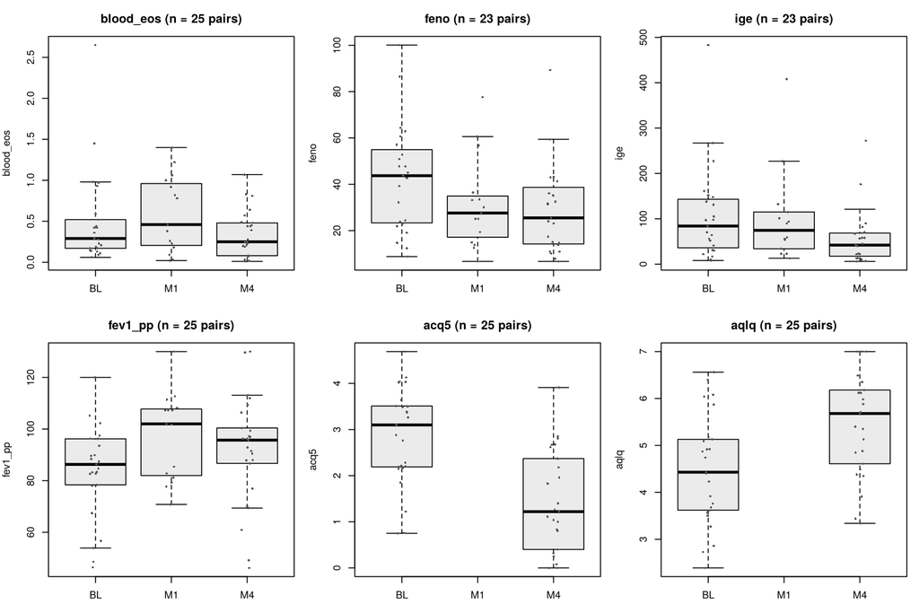

```r
ch <- rd("clinical/change_BLtoM4/change.csv")
kt(ch[, c("variable", "n_pairs", "test", "summary_BL", "summary_M1", "summary_M4",
          "estimate_type", "estimate", "ci_low", "ci_high", "p_value")])
```

Clinical response at 4 months, as defined in the paper:

```r
w <- reshape(meta[meta$visit %in% c("BL", "M4"), c("subject_id", "visit", "acq5", "fev1_pp")],
             idvar = "subject_id", timevar = "visit", direction = "wide")
data.frame(
  criterion = c("ACQ decrease >= 0.5", "ACQ < 1.5 at 4 months", "FEV1 improvement >= 10 % points"),
  n = c(sum(w$acq5.BL - w$acq5.M4 >= 0.5), sum(w$acq5.M4 < 1.5), sum(w$fev1_pp.M4 - w$fev1_pp.BL >= 10)),
  paper = c(22, 15, 10))
```

| criterion | n | paper |
| --- | --- | --- |
| ACQ decrease >= 0.5 | 24 | 22 |
| ACQ < 1.5 at 4 months | 15 | 15 |
| FEV1 improvement >= 10 % points | 6 | 10 |

The paper’s “≥10%” FEV1 improvement could mean percentage points or a relative change; percentage points are used here.

# 6 Missing data (added)

The paper does not say how it handled fragments below detection, missing clinical values or the incomplete 1-month visit. The `prep-missing-data` skill makes these choices explicit. In GC-MS tables, zeros mean “below detection”, so they are treated as missing here (the `gcms_intensity` scale does this automatically).

```r
skill(file.path(K, "prep-missing-data/scripts/missing_data.R"),
      c(paste0("--config=", CFG), "--mode=diagnose", "--layer=breath_voc",
        "--clinical=acq5,aqlq,blood_eos,feno,ige,fev1_pp"),
      done = file.path(RES, "missing/diagnose_breath_voc/summary.txt"), show = 0)
```

```
## [cached] Rscript .claude/skills/prep-missing-data/scripts/missing_data.R --config=usecases/01_breathomics_biologics/study_config.json --mode=diagnose --layer=breath_voc --clinical=acq5,aqlq,blood_eos,feno,ige,fev1_pp
```

```
## Missing-data diagnosis: layer breath_voc (gcms_intensity scale)
## Overall missing: 3.00% of 277550 values | features with any missing: 856 of 4270 | > 50% missing: 50
## Samples: median 2.9% missing (max 4.7%, ABC005_M1)
## Missing by visit (mean % per feature): BL 2.9; M1 3.0; M4 3.0
## Intensity vs missingness (Spearman, features with partial missingness): -0.66
##   -> strong negative: low-abundance values go missing = left-censored (MNAR). Prefer halfmin / minprob; kNN/BPCA assume MAR and will overestimate.
## Sample missingness vs design (Kruskal-Wallis p):
##   visit: 0.855
##   group: 0.56
##   gcms_batch: 0.00826
##   site: 0.558
##   -> missingness differs by a design variable: impute WITHIN-group-agnostic methods and report it; consider it a potential confounder.
## Subject follow-up pattern (whole visits missing):
## pattern
##     complete intermittent
##           15           10
##   Whole missing visits are handled by mixed models (stats-mixed-models) under MAR; do not impute whole visits.
##
## Clinical variables: number missing by visit
##    acq5 aqlq blood_eos feno ige fev1_pp
## BL    0    0         0    2   2       0
## M1   15   15         0    0   1       0
## M4    0    0         0    2   2       0
```

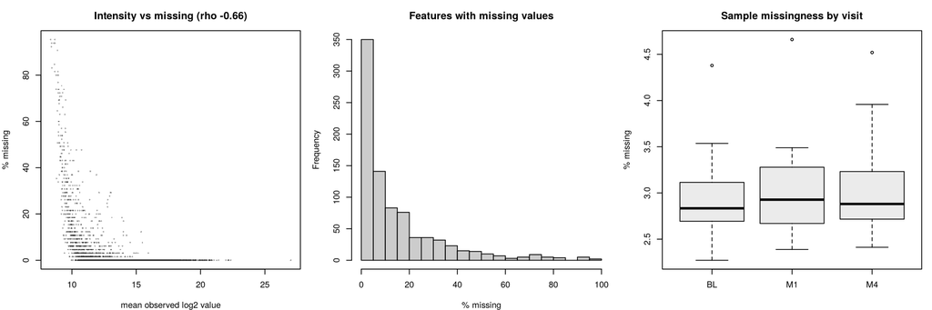

```r
cat(readLines(file.path(RES, "missing/diagnose_breath_voc/summary.txt")), sep = "\n")
```

Low-intensity fragments have more missing values, which is the signature of left-censoring (MNAR). To check which imputation recovers hidden values best, the benchmark masks 5% of the *observed* values, either at random (MCAR) or among each fragment’s lowest values (MNAR), imputes them and scores each method against the truth:

```r
skill(file.path(K, "prep-missing-data/scripts/missing_data.R"),
      c(paste0("--config=", CFG), "--mode=benchmark", "--layer=breath_voc", "--reps=3"),
      done = file.path(RES, "missing/benchmark_breath_voc/benchmark_summary.csv"), show = 0)
```

```
## [cached] Rscript .claude/skills/prep-missing-data/scripts/missing_data.R --config=usecases/01_breathomics_biologics/study_config.json --mode=benchmark --layer=breath_voc --reps=3
```

```r
kt(rd("missing/benchmark_breath_voc/benchmark_summary.csv"))
```

| mechanism | method | rmse | nrmse | bias | spearman |
| --- | --- | --- | --- | --- | --- |
| MCAR | knn | 1.167 | 0.418 | -0.110 | 0.914 |
| MCAR | mean | 1.566 | 0.561 | -0.007 | 0.822 |
| MCAR | halfmin | 4.448 | 1.595 | -4.048 | 0.753 |
| MCAR | minprob | 6.053 | 2.170 | -5.206 | 0.004 |
| MNAR | knn | 1.502 | 0.538 | 1.311 | 0.940 |
| MNAR | halfmin | 2.093 | 0.750 | -1.936 | 0.925 |
| MNAR | mean | 2.329 | 0.835 | 2.127 | 0.910 |
| MNAR | minprob | 4.027 | 1.444 | -3.100 | 0.001 |

How to read it: NRMSE is the error (lower is better). Bias is the direction: a negative value means imputed values are too low, as half-minimum is by design. The preprocessing below keeps the paper-style half-minimum. `--mode=impute --method=knn` would write a `breath_voc_imp_knn` layer for a sensitivity analysis.

Whole missing visits (10 patients without a 1-month sample) are **not imputed**; the mixed models in section 13 handle them. The missing FeNO and IgE values (2 patients each) are left out of the paired tests (complete pairs) and kept in the mixed models.

# 7 GC-MS preprocessing (Methods 2.5, Suppl. Fig. 1)

The paper’s processing order is: XCMS → contaminant removal → log transform → z-score → PCA to check batch → `limma` batch correction. The engine starts from the aligned XCMS table, because raw chromatograms are not part of the data contract.

```r
skill(file.path(K, "prep-breathomics-gcms/scripts/breath_preprocess.R"),
      c(paste0("--config=", CFG), "--layer=breath_voc"),
      done = file.path(RES, "data/breath_voc_processed_se.rds"), show = 0)
```

```
## [cached] Rscript .claude/skills/prep-breathomics-gcms/scripts/breath_preprocess.R --config=usecases/01_breathomics_biologics/study_config.json --layer=breath_voc
```

```
## Layer: breath_voc | samples: 65 | fragments in: 4270
## Known contaminants removed: 1062 -> 3208 fragments remain
## Zero/missing filter: off (--zero_max=1)
## log2 transform; 6635 zero/NA values (3.18%) set to half the fragment minimum
##
## Batch (gcms_batch) x visit:
##     pv
## b    BL M1 M4
##   B1  7  6  6
##   B2  7  4  8
##   B3  5  1  8
##   B4  6  4  3
## Cramer's V (batch vs visit) = 0.20
## limma::removeBatchEffect(batch = gcms_batch, design = ~ visit)
## NOTE: each batch belongs to one site, so batch correction also removes between-site differences.
##
## PC1-5 association p-values BEFORE batch correction:
##     gcms_batch visit group    site
## PC1    3.1e-01  0.95  0.93 3.9e-01
## PC2    1.2e-07  0.77  0.64 1.1e-08
## PC3    3.5e-12  0.54  0.80 1.0e+00
## PC4    1.9e-02  0.34  0.22 8.7e-03
## PC5    7.7e-11  0.26  0.18 8.0e-01
##
## PC1-5 association p-values AFTER batch correction:
##     gcms_batch visit group site
## PC1       1.00  0.95 0.650 0.88
## PC2       0.94  0.89 0.520 0.99
## PC3       1.00  0.59 0.540 1.00
## PC4       1.00  0.75 0.220 0.96
## PC5       0.92  0.98 0.085 0.81
```

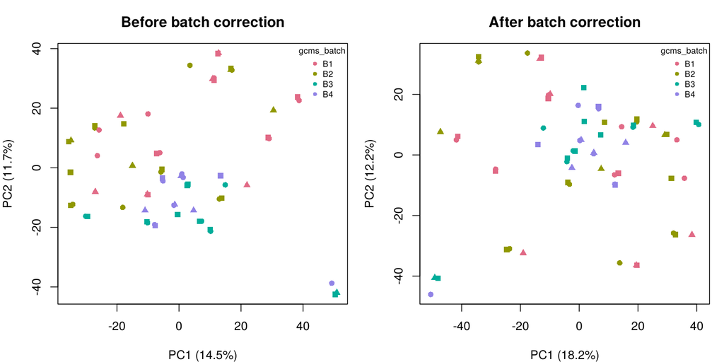

```r
cat(readLines(file.path(RES, "qc/breath_voc_breath_qc.txt")), sep = "\n")
```

As in the paper, 4,270 fragments go in and 3,208 remain after contaminant removal. Batch correction removes the batch structure from the leading PCs. Here batches are nested within site, so the correction also removes site differences; the QC file flags this.

# 8 Multilevel sPLS-DA: baseline vs 4 months (Fig. 3, Table 2)

The paper’s model, with its settings:

- fragments z-scored, **multilevel** decomposition (within-patient variation only);
- sPLS-DA with keepX tuned, then **stepwise backward elimination**: a feature is kept only if removing it drops the AUC by more than 5%, with a target AUC of about 0.9;
- AUROC of the final model on the full data, then **leave-one-subject-out CV** with the panel fixed.

The skill also adds a **nested cross-validation**, which repeats tuning and elimination inside every outer fold (patient-grouped 5-fold × 5 repeats), and a **within-patient permutation null**. These are the checks the paper’s design needs.

```r
run <- "splsda/BLvsM4_breath_voc"
skill(file.path(K, "ml-multilevel-splsda/scripts/multilevel_splsda.R"),
      c(paste0("--config=", CFG), "--layer=breath_voc", "--visits=BL,M4",
        "--drop_max=0.05", "--target_auc=0.9", "--elim_auc=train",
        paste0("--n_perm=", params$n_perm), "--plot_visits=BL,M1,M4", "--colour_by=biologic"),
      done = file.path(RES, run, "performance.csv"), show = 0)
```

```
## [cached] Rscript .claude/skills/ml-multilevel-splsda/scripts/multilevel_splsda.R --config=usecases/01_breathomics_biologics/study_config.json --layer=breath_voc --visits=BL,M4 --drop_max=0.05 --target_auc=0.9 --elim_auc=train --n_perm=20 --plot_visits=BL,M1,M4 --colour_by=biologic
```

```r
tun <- rd(run, "tuning.csv"); el <- rd(run, "elimination_log.csv")
cat(sprintf("Tuned keepX per component: %s; %d fragments entered elimination; final panel: %d\n",
            paste(tun$keepX[tapply(seq_len(nrow(tun)), tun$comp, function(i) i[which.max(tun$loso_auc[i])])], collapse = ", "),
            el$n_features[1], utils::tail(el$n_features, 1)))
```

```
## Tuned keepX per component: 50, 5; 55 fragments entered elimination; final panel: 2
```

```r
kt(utils::tail(el, 8))
```

| step | removed | n_features | auc | decision |
| --- | --- | --- | --- | --- |
| 46 | MZ137_RT1144 | 9 | 1.000 | removed (AUC change +0.000) |
| 47 | MZ053_RT0325 | 8 | 1.000 | removed (AUC change +0.000) |
| 48 | MZ074_RT0378 | 7 | 1.000 | removed (AUC change +0.000) |
| 49 | MZ039_RT0933 | 6 | 1.000 | removed (AUC change +0.000) |
| 50 | MZ093_RT1449 | 5 | 0.998 | removed (AUC change -0.002) |
| 51 | MZ079_RT0662 | 4 | 0.995 | removed (AUC change -0.003) |
| 52 | MZ141_RT1143 | 3 | 0.986 | removed (AUC change -0.010) |
| 53 | MZ052_RT0496 | 2 | 0.986 | removed (AUC change +0.000) |

**Table 2 equivalent: the selected panel**

```r
panel <- rd(run, "panel.csv")
panel$planted <- ifelse(panel$feature %in% truth$feature[truth$type == "time_effect"], "planted VOC",
                 ifelse(panel$feature %in% truth$feature, "planted background", "noise"))
kt(panel[, c("feature", "compound", "mz", "rt_s", "class", "formula", "direction", "n_up", "n_down", "planted")])
```

| feature | compound | mz | rt_s | class | formula | direction | n_up | n_down | planted |
| --- | --- | --- | --- | --- | --- | --- | --- | --- | --- |
| MZ098_RT1193 | 5-methyloctadecane | 98 | 1193 | Alkanes | C19H40 | decrease | 5 | 20 | planted VOC |
| MZ104_RT1080 | 2-methylundecane | 104 | 1080 | Alkanes | C12H26 | decrease | 3 | 22 | planted VOC |

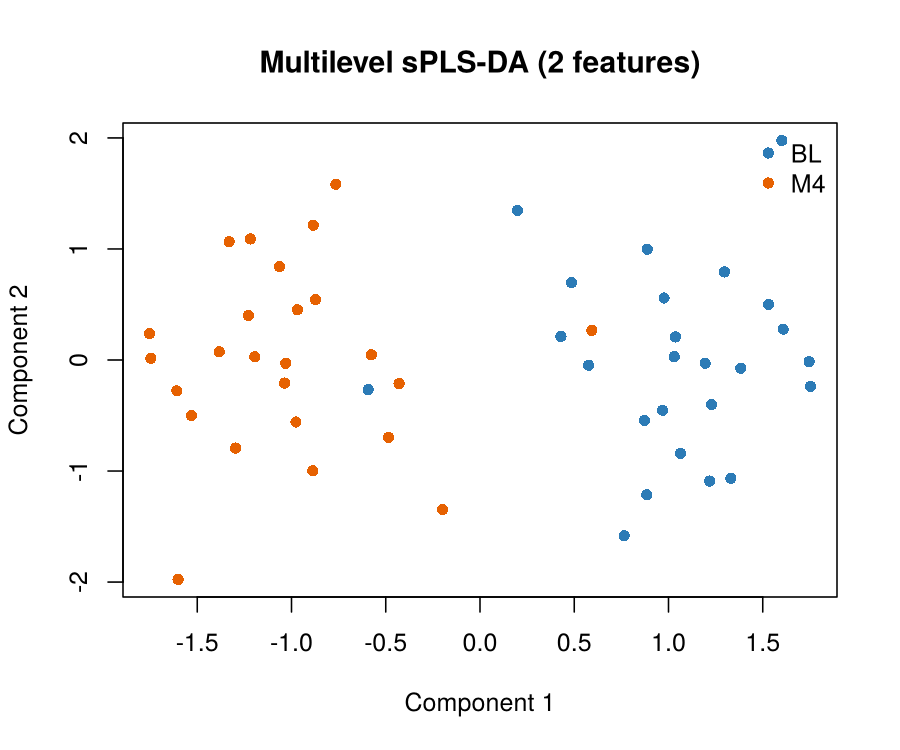

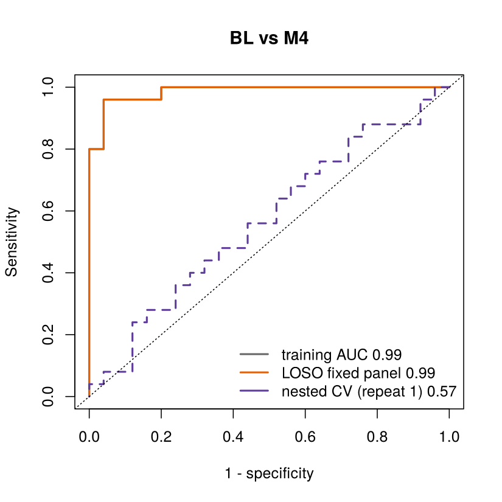

**Performance: four estimates**

```r
perf <- rd(run, "performance.csv")
kt(perf[, c("estimate", "auc", "auc_ci_low", "auc_ci_high", "paired_acc", "perm_null_mean_auc", "perm_p_auc")])
```

| estimate | auc | auc_ci_low | auc_ci_high | paired_acc | perm_null_mean_auc | perm_p_auc |
| --- | --- | --- | --- | --- | --- | --- |
| A_training (selection on all data) | 0.986 | 0.963 | 1.000 | 0.960 | 0.956 | 0.238 |
| B_LOSO_fixed_panel (panel selected on all data) | 0.986 | 0.963 | 1.000 | 0.960 | 0.941 | 0.095 |
| C_nested_5fold_x5 (selection inside each fold; mean [min-max] over repeats) | 0.702 | 0.566 | 0.802 | 0.648 | NA | NA |

```r
perm <- rd(run, "permutation.csv")
summary(perm[, c("n_features", "auc_train", "auc_loso_fixed_panel", "paired_acc_loso_fixed_panel")])
```

```
##    n_features    auc_train      auc_loso_fixed_panel
##  Min.   :1.0   Min.   :0.9016   Min.   :0.8920
##  1st Qu.:2.0   1st Qu.:0.9376   1st Qu.:0.9168
##  Median :2.0   Median :0.9608   Median :0.9416
##  Mean   :1.8   Mean   :0.9564   Mean   :0.9407
##  3rd Qu.:2.0   3rd Qu.:0.9800   3rd Qu.:0.9644
##  Max.   :2.0   Max.   :1.0000   Max.   :0.9888
##  paired_acc_loso_fixed_panel
##  Min.   :0.760
##  1st Qu.:0.800
##  Median :0.840
##  Mean   :0.848
##  3rd Qu.:0.880
##  Max.   :0.960
```

How to read this:

- **A (training)** and **B (LOSO, panel fixed)** are the two estimates the paper reports (0.89 and 0.78 there). The panel was chosen on the same 25 patients for both, so neither is an independent estimate.
- The **permutation null** reruns the same pipeline after flipping BL/M4 labels within random patients, so there is *no* treatment effect. It still gives training AUCs around 0.96 and LOSO AUCs around 0.94. The observed training AUC sits at permutation *p* = 0.24 (20 permutations). With about 3,000 fragments, about 25 pairs and within-patient centring, high A and B values are expected **even without a real effect**. An A or B value alone therefore cannot show that VOCs changed.
- **C (nested CV)** is the honest estimate. Use paired accuracy (the share of patients whose 4-month sample scores higher than their baseline sample), not pooled AUC: each fold’s model puts scores on its own scale. The table gives the mean over 5 repeats, with the min–max range in the CI columns. Nested *leave-one-subject-out* is available (`--nested_folds=loso`) but is biased downwards when selection is this aggressive (see the skill’s SKILL.md).

Per-repeat nested results, and how often each panel feature was selected again across the 25 nested fold fits:

```r
kt(rd(run, "nested_repeats.csv"))
```

| repeat_id | auc | paired_acc |
| --- | --- | --- |
| 1 | 0.566 | 0.56 |
| 2 | 0.685 | 0.56 |
| 3 | 0.802 | 0.76 |
| 4 | 0.662 | 0.64 |
| 5 | 0.797 | 0.72 |

```r
np <- rd(run, "nested_panels.csv")
fr <- table(unlist(strsplit(np$features, ";")))
data.frame(feature = panel$feature, compound = panel$compound,
           fold_fits_selected = as.integer(ifelse(is.na(fr[panel$feature]), 0, fr[panel$feature])), of = nrow(np))
```

| feature | compound | fold_fits_selected | of |
| --- | --- | --- | --- |
| MZ098_RT1193 | 5-methyloctadecane | 10 | 25 |
| MZ104_RT1080 | 2-methylundecane | 6 | 25 |

```r
kt(as.data.frame(sort(fr, decreasing = TRUE)[1:8], responseName = "fold_fits"), col.names = c("feature (top 8 across nested fits)", "fold fits"))
```

| feature (top 8 across nested fits) | fold fits |
| --- | --- |
| MZ098_RT1193 | 10 |
| MZ104_RT1080 | 6 |
| MZ052_RT0496 | 4 |
| MZ079_RT0662 | 2 |
| MZ141_RT1143 | 2 |
| MZ214_RT0818 | 2 |
| MZ275_RT1108 | 2 |
| MZ163_RT0688 | 1 |

**Recall of the planted truth.** The tuned sPLS-DA model, before elimination, contained 5 of the 5 planted VOCs. The elimination rule then cut it down to the smallest set that keeps the training AUC ≥ 0.9.

# 9 The published 5-VOC panel as a fixed panel (Fig. 4)

To mirror the paper’s figures for the five compounds it reports, we evaluate that panel directly, with no selection (`--panel`). In the simulation these are the planted VOCs.

```r
v5 <- truth$feature[truth$type == "time_effect"]
run5 <- "splsda/BLvsM4_breath_voc_paper5"
skill(file.path(K, "ml-multilevel-splsda/scripts/multilevel_splsda.R"),
      c(paste0("--config=", CFG), "--layer=breath_voc", "--visits=BL,M4",
        paste0("--panel=", paste(v5, collapse = ",")), "--plot_visits=BL,M1,M4",
        "--colour_by=biologic", "--tag=paper5"),
      done = file.path(RES, run5, "performance.csv"), show = 0)
```

```
## [cached] Rscript .claude/skills/ml-multilevel-splsda/scripts/multilevel_splsda.R --config=usecases/01_breathomics_biologics/study_config.json --layer=breath_voc --visits=BL,M4 --panel=MZ052_RT0496,MZ039_RT0933,MZ098_RT1193,MZ104_RT1080,MZ141_RT1143 --plot_visits=BL,M1,M4 --colour_by=biologic --ta…
```

```r
kt(rd(run5, "performance.csv")[1:2, c("estimate", "auc", "auc_ci_low", "auc_ci_high", "paired_acc")])
```

| estimate | auc | auc_ci_low | auc_ci_high | paired_acc |
| --- | --- | --- | --- | --- |
| A_training (selection on all data) | 1 | 1 | 1 | 1 |
| B_LOSO_fixed_panel (panel selected on all data) | 1 | 1 | 1 | 1 |

```r
kt(rd(run5, "panel.csv")[, c("compound", "class", "loading_comp1", "mean_change_z", "direction", "n_up", "n_down")])
```

| compound | class | loading_comp1 | mean_change_z | direction | n_up | n_down |
| --- | --- | --- | --- | --- | --- | --- |
| methyl isobutyl ketone | Ketones | 0.453 | -0.639 | decrease | 5 | 20 |
| 2-ethyl-1-hexanol | Fatty alcohols | -0.408 | 0.486 | increase | 20 | 5 |
| 5-methyloctadecane | Alkanes | 0.474 | -0.654 | decrease | 5 | 20 |
| 2-methylundecane | Alkanes | 0.455 | -0.825 | decrease | 3 | 22 |
| 1,1’-oxybis(decane) | Ethers | 0.444 | -0.600 | decrease | 3 | 22 |

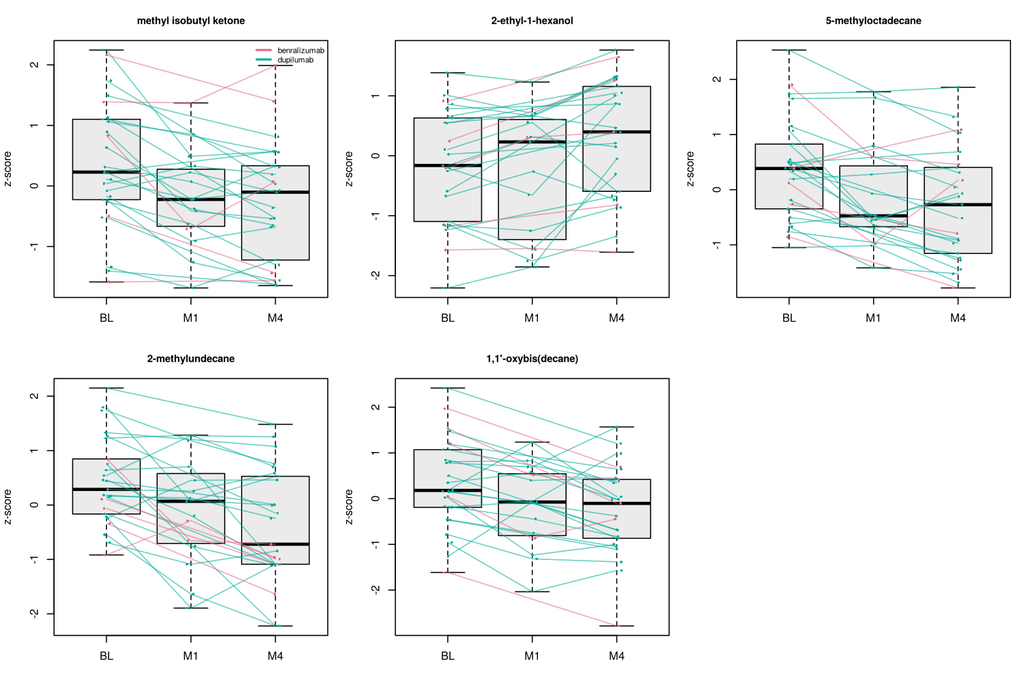

Lines connect each patient’s visits and are coloured by biologic. As planted, methyl isobutyl ketone and the alkanes/ether decrease, and 2-ethyl-1-hexanol increases.

# 10 Baseline VOC–clinical correlations (Table 4)

```r
skill(file.path(K, "stats-clinical-association/scripts/clinical_association.R"),
      c(paste0("--config=", CFG), "--mode=correlation", "--layer=breath_voc",
        paste0("--features=", paste(v5, collapse = ",")), "--vars=acq5,blood_eos,ige,feno,fev1_pp",
        "--visit=BL", paste0("--boot=", params$boot), "--tag=BL_paper5"),
      done = file.path(RES, "clinical/correlation_BL_paper5/kendall.csv"), show = 0)
```

```
## [cached] Rscript .claude/skills/stats-clinical-association/scripts/clinical_association.R --config=usecases/01_breathomics_biologics/study_config.json --mode=correlation --layer=breath_voc --features=MZ052_RT0496,MZ039_RT0933,MZ098_RT1193,MZ104_RT1080,MZ141_RT1143 --vars=acq5,blood_eos,ige,feno,f…
```

```r
kt(rd("clinical/correlation_BL_paper5/kendall_table.csv"))
```

| clinical | methyl isobutyl ketone | 2-ethyl-1-hexanol | 5-methyloctadecane | 2-methylundecane | 1,1’-oxybis(decane) |
| --- | --- | --- | --- | --- | --- |
| acq5 | tau 0.13, z = 0.93, p = 0.35 | tau 0.48, z = 3.36, p = 0.000771 | tau 0.02, z = 0.14, p = 0.889 | tau 0.04, z = 0.28, p = 0.779 | tau 0.29, z = 2.01, p = 0.0446 |
| blood_eos | tau -0.01, z = -0.05, p = 0.963 | tau -0.33, z = -2.34, p = 0.0195 | tau -0.15, z = -1.07, p = 0.282 | tau -0.19, z = -1.36, p = 0.175 | tau -0.43, z = -3.04, p = 0.00238 |
| ige | tau -0.12, z = -0.82, p = 0.413 | tau 0.07, z = 0.45, p = 0.653 | tau 0.12, z = 0.82, p = 0.413 | tau -0.13, z = -0.87, p = 0.383 | tau -0.08, z = -0.55, p = 0.579 |
| feno | tau 0.03, z = 0.18, p = 0.853 | tau -0.12, z = -0.82, p = 0.413 | tau -0.06, z = -0.40, p = 0.692 | tau -0.19, z = -1.29, p = 0.196 | tau -0.39, z = -2.61, p = 0.00893 |
| fev1_pp | tau -0.01, z = -0.07, p = 0.944 | tau -0.33, z = -2.31, p = 0.0207 | tau -0.04, z = -0.30, p = 0.761 | tau 0.05, z = 0.35, p = 0.726 | tau -0.38, z = -2.64, p = 0.00829 |

```r
kd <- rd("clinical/correlation_BL_paper5/kendall.csv")
kt(kd[kd$p_value < 0.05, c("label", "clinical", "n", "tau", "z", "p_value", "tau_ci_low", "tau_ci_high")])
```

| label | clinical | n | tau | z | p_value | tau_ci_low | tau_ci_high |
| --- | --- | --- | --- | --- | --- | --- | --- |
| 2-ethyl-1-hexanol | acq5 | 25 | 0.480 | 3.363 | 0.001 | 0.200 | 0.707 |
| 2-ethyl-1-hexanol | blood_eos | 25 | -0.334 | -2.337 | 0.019 | -0.602 | -0.018 |
| 2-ethyl-1-hexanol | fev1_pp | 25 | -0.331 | -2.313 | 0.021 | -0.550 | -0.073 |
| 1,1’-oxybis(decane) | acq5 | 25 | 0.287 | 2.009 | 0.045 | 0.031 | 0.507 |
| 1,1’-oxybis(decane) | blood_eos | 25 | -0.435 | -3.038 | 0.002 | -0.662 | -0.170 |
| 1,1’-oxybis(decane) | feno | 23 | -0.391 | -2.615 | 0.009 | -0.621 | -0.143 |
| 1,1’-oxybis(decane) | fev1_pp | 25 | -0.377 | -2.640 | 0.008 | -0.592 | -0.124 |

The two planted baseline traits are recovered: 2-ethyl-1-hexanol with ACQ (positive) and 1,1′-oxybis(decane) with blood eosinophils (negative). There are 25 unadjusted tests here, so about one would fall below *p* < 0.05 by chance; any extra “hits” in the table should be read that way. After BH adjustment:

```r
kd$p_BH <- p.adjust(kd$p_value, "BH")
kt(kd[order(kd$p_BH)[1:4], c("label", "clinical", "tau", "p_value", "p_BH")])
```

| label | clinical | tau | p_value | p_BH |
| --- | --- | --- | --- | --- |
| 2-ethyl-1-hexanol | acq5 | 0.480 | 0.001 | 0.019 |
| 1,1’-oxybis(decane) | blood_eos | -0.435 | 0.002 | 0.030 |
| 1,1’-oxybis(decane) | feno | -0.391 | 0.009 | 0.056 |
| 1,1’-oxybis(decane) | fev1_pp | -0.377 | 0.008 | 0.056 |

# 11 Influence of medication (Section 3.6)

```r
skill(file.path(K, "stats-clinical-association/scripts/clinical_association.R"),
      c(paste0("--config=", CFG), "--mode=exposure", "--layer=breath_voc",
        paste0("--features=", paste(v5, collapse = ",")),
        "--exposures=ocs_maintenance,lama,ltra,ics_dose", "--visit=BL", "--tag=BL_paper5"),
      done = file.path(RES, "clinical/exposure_BL_paper5/exposure_tests.csv"), show = 0)
```

```
## [cached] Rscript .claude/skills/stats-clinical-association/scripts/clinical_association.R --config=usecases/01_breathomics_biologics/study_config.json --mode=exposure --layer=breath_voc --features=MZ052_RT0496,MZ039_RT0933,MZ098_RT1193,MZ104_RT1080,MZ141_RT1143 --exposures=ocs_maintenance,lama,lt…
```

```r
ex <- rd("clinical/exposure_BL_paper5/exposure_tests.csv")
kt(ex[order(ex$p_value)[1:6], c("exposure", "label", "groups", "test", "p_value")])
```

| exposure | label | groups | test | p_value |
| --- | --- | --- | --- | --- |
| ics_dose | 2-methylundecane | <= median: n=14, median 9.44; > median (1500): n=11, median 10.09 | Mann-Whitney U | 0.119 |
| ltra | methyl isobutyl ketone | no: n=8, median 12.89; yes: n=17, median 13.87 | Mann-Whitney U | 0.171 |
| ics_dose | 2-ethyl-1-hexanol | <= median: n=14, median 14.03; > median (1500): n=11, median 15.32 | Mann-Whitney U | 0.239 |
| lama | 2-ethyl-1-hexanol | no: n=13, median 15.32; yes: n=12, median 14.29 | Mann-Whitney U | 0.242 |
| ocs_maintenance | 1,1’-oxybis(decane) | no: n=21, median 15.17; yes: n=4, median 14.73 | Mann-Whitney U | 0.282 |
| lama | 5-methyloctadecane | no: n=13, median 12.58; yes: n=12, median 12.21 | Mann-Whitney U | 0.289 |

No medication was planted in the simulation, so any small *p*-values here are chance. With only 4 patients on maintenance OCS, this test has almost no power.

# 12 VOC change by biologic

The paper saw no visual difference in VOC trajectories between biologics. The engine’s existing `stats-group-testing` skill tests that directly. It compares the change from baseline (M4 − BL) between dupilumab (n = 20) and benralizumab (n = 5) for every fragment, with FDR correction.

```r
skill(file.path(K, "stats-group-testing/scripts/group_tests.R"),
      c(paste0("--config=", CFG), "--design=between", "--by=group", "--visit=M4",
        "--change_from=BL", "--layers=breath_voc"),
      done = file.path(RES, "tests/between_group_M4_minusBL/breath_voc_tests.csv"), show = 0)
```

```
## [cached] Rscript .claude/skills/stats-group-testing/scripts/group_tests.R --config=usecases/01_breathomics_biologics/study_config.json --design=between --by=group --visit=M4 --change_from=BL --layers=breath_voc
```

```r
bt <- rd("tests/between_group_M4_minusBL/breath_voc_tests.csv")
cat(sprintf("%d fragments; min FDR (Wilcoxon) = %.2f\n", nrow(bt), min(bt$fdr_wilcox, na.rm = TRUE)))
```

```
## 3208 fragments; min FDR (Wilcoxon) = 0.96
```

```r
kt(bt[bt$feature %in% v5, intersect(c("feature", "comparison", "mean_diff", "cohens_d", "p_wilcox", "fdr_wilcox"), names(bt))])
```

| feature | comparison | mean_diff | cohens_d | p_wilcox | fdr_wilcox |
| --- | --- | --- | --- | --- | --- |
| MZ141_RT1143 | dupilumab - benralizumab | 0.819 | 0.985 | 0.062 | 0.962 |
| MZ052_RT0496 | dupilumab - benralizumab | -0.437 | -0.527 | 0.519 | 0.970 |
| MZ104_RT1080 | dupilumab - benralizumab | 0.294 | 0.271 | 0.476 | 0.970 |
| MZ098_RT1193 | dupilumab - benralizumab | -0.368 | -0.465 | 0.564 | 0.978 |
| MZ039_RT0933 | dupilumab - benralizumab | -0.079 | -0.095 | 0.610 | 0.983 |

With 5 benralizumab patients, only very large between-drug differences could be detected. “No difference” here means “not detectable”, not “the same”.

# 13 Mixed-effects models using all three visits (added)

The paper’s tests use only the patients with both baseline and 4-month samples, and the 1-month visit enters only the plots. A **linear mixed model** uses every available sample, keeping the 10 patients without a 1-month breath sample. It also models within-patient correlation with a random intercept:

`y ~ visit × biologic + (1 | patient)`

Here `visit` is a factor (BL, M1, M4), so no shape is assumed. The time effect, the time × biologic interaction and the time effect within each biologic are likelihood-ratio tests. Changes versus baseline come from `emmeans`. The skill is `stats-mixed-models`.

## 13.1 Clinical trajectories

```r
skill(file.path(K, "stats-mixed-models/scripts/mixed_models.R"),
      c(paste0("--config=", CFG), "--mode=clinical", "--vars=blood_eos,feno,ige,fev1_pp,acq5,aqlq",
        "--log=blood_eos,feno,ige", "--by=group"),
      done = file.path(RES, "mixed/clinical_factor_bygroup_intercept/lmm_results.csv"), show = 0)
```

```
## [cached] Rscript .claude/skills/stats-mixed-models/scripts/mixed_models.R --config=usecases/01_breathomics_biologics/study_config.json --mode=clinical --vars=blood_eos,feno,ige,fev1_pp,acq5,aqlq --log=blood_eos,feno,ige --by=group
```

```r
lc <- rd("mixed/clinical_factor_bygroup_intercept/lmm_results.csv")
kt(lc[, c("label", "n_obs", "n_subjects", "p_time", "fdr_time", "p_interaction", "fdr_interaction",
          "p_time_benralizumab", "p_time_dupilumab", "icc")])
```

| label | n_obs | n_subjects | p_time | fdr_time | p_interaction | fdr_interaction | p_time_benralizumab | p_time_dupilumab | icc |
| --- | --- | --- | --- | --- | --- | --- | --- | --- | --- |
| log ige | 60 | 23 | 0.000 | 0.000 | 0.000 | 0.000 | 0.020 | 0.000 | 0.978 |
| log blood_eos | 65 | 25 | 0.000 | 0.000 | 0.000 | 0.000 | 0.000 | 0.003 | 0.648 |
| log feno | 61 | 23 | 0.000 | 0.000 | 0.000 | 0.000 | 0.008 | 0.000 | 0.911 |
| acq5 | 50 | 25 | 0.000 | 0.000 | 0.416 | 0.624 | 0.003 | 0.000 | 0.714 |
| aqlq | 50 | 25 | 0.000 | 0.000 | 0.899 | 0.943 | 0.030 | 0.000 | 0.790 |
| fev1_pp | 65 | 25 | 0.001 | 0.001 | 0.943 | 0.943 | 0.144 | 0.001 | 0.906 |

```r
cc <- rd("mixed/clinical_factor_bygroup_intercept/contrasts.csv")
kt(cc[cc$variable %in% c("blood_eos", "feno"), c("label", "contrast", ".grp", "estimate", "lower.CL", "upper.CL", "p.value")])
```

| label | contrast | .grp | estimate | lower.CL | upper.CL | p.value |
| --- | --- | --- | --- | --- | --- | --- |
| log blood_eos | M1 - BL | benralizumab | -2.986 | -3.897 | -2.076 | 0.000 |
| log blood_eos | M4 - BL | benralizumab | -3.385 | -4.020 | -2.750 | 0.000 |
| log blood_eos | M1 - BL | dupilumab | 0.496 | 0.123 | 0.869 | 0.011 |
| log blood_eos | M4 - BL | dupilumab | 0.123 | -0.195 | 0.440 | 0.439 |
| log feno | M1 - BL | benralizumab | 0.426 | 0.041 | 0.811 | 0.031 |
| log feno | M4 - BL | benralizumab | 0.202 | -0.127 | 0.531 | 0.220 |
| log feno | M1 - BL | dupilumab | -0.456 | -0.606 | -0.305 | 0.000 |
| log feno | M4 - BL | dupilumab | -0.527 | -0.654 | -0.400 | 0.000 |

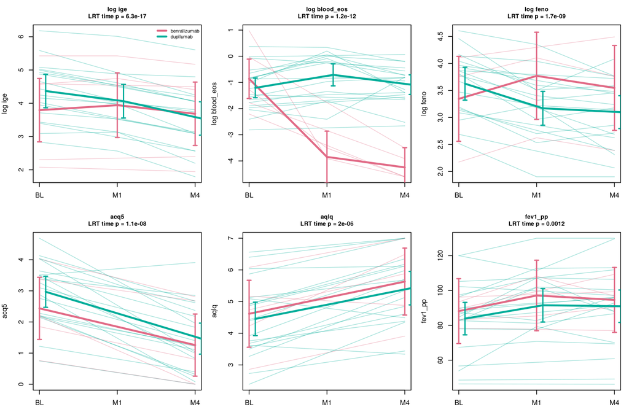

The models show what Table 3 hides by pooling both drugs. Eosinophils **rise transiently on dupilumab (largest at 1 month) and collapse on benralizumab**: the interaction is the strongest effect in the table. FeNO and IgE fall mainly on dupilumab. On the log scale, contrasts are differences in log units, so exp(estimate) is the ratio to baseline. ACQ and AQLQ were not collected at 1 month, so they contribute only BL and M4.

## 13.2 VOCs: every fragment, all visits

```r
skill(file.path(K, "stats-mixed-models/scripts/mixed_models.R"),
      c(paste0("--config=", CFG), "--mode=features", "--layer=breath_voc", "--by=group", "--report_top=12"),
      done = file.path(RES, "mixed/features_breath_voc_factor_bygroup_intercept/lmm_results.csv"), show = 0)
```

```
## [cached] Rscript .claude/skills/stats-mixed-models/scripts/mixed_models.R --config=usecases/01_breathomics_biologics/study_config.json --mode=features --layer=breath_voc --by=group --report_top=12
```

```r
lv <- rd("mixed/features_breath_voc_factor_bygroup_intercept/lmm_results.csv")
lv$planted <- ifelse(lv$variable %in% v5, "planted VOC", ifelse(lv$variable %in% truth$feature, "planted background", ""))
cat(sprintf("%d fragments; time effect FDR < 0.05: %d; time x biologic FDR < 0.05: %d\n",
            nrow(lv), sum(lv$fdr_time < 0.05), sum(lv$fdr_interaction < 0.05)))
```

```
## 3208 fragments; time effect FDR < 0.05: 2; time x biologic FDR < 0.05: 2
```

```r
kt(head(lv[, c("variable", "label", "p_time", "fdr_time", "p_interaction", "fdr_interaction", "icc", "planted")], 12))
```

| variable | label | p_time | fdr_time | p_interaction | fdr_interaction | icc | planted |
| --- | --- | --- | --- | --- | --- | --- | --- |
| MZ098_RT1193 | 5-methyloctadecane | 0.000 | 0.023 | 0.112 | 0.700 | 0.836 | planted VOC |
| MZ052_RT0496 | methyl isobutyl ketone | 0.000 | 0.023 | 0.252 | 0.829 | 0.835 | planted VOC |
| MZ170_RT1157 | MZ170_RT1157 | 0.000 | 0.093 | 0.000 | 0.045 | 0.774 |  |
| MZ141_RT1143 | 1,1’-oxybis(decane) | 0.000 | 0.097 | 0.085 | 0.698 | 0.815 | planted VOC |
| MZ104_RT1080 | 2-methylundecane | 0.000 | 0.097 | 0.815 | 0.956 | 0.626 | planted VOC |
| MZ067_RT0980 | MZ067_RT0980 | 0.000 | 0.124 | 0.000 | 0.070 | 0.809 |  |
| MZ157_RT1367 | MZ157_RT1367 | 0.000 | 0.124 | 0.000 | 0.045 | 0.806 |  |
| MZ116_RT1120 | MZ116_RT1120 | 0.000 | 0.124 | 0.000 | 0.085 | 0.792 |  |
| MZ277_RT0745 | MZ277_RT0745 | 0.000 | 0.134 | 0.119 | 0.703 | 0.835 |  |
| MZ096_RT1196 | MZ096_RT1196 | 0.001 | 0.161 | 0.171 | 0.751 | 0.854 |  |
| MZ182_RT1280 | MZ182_RT1280 | 0.001 | 0.161 | 0.791 | 0.955 | 0.768 |  |
| MZ079_RT0662 | MZ079_RT0662 | 0.001 | 0.161 | 0.145 | 0.736 | 0.719 |  |

```r
cat("Rank of the planted VOCs by time-effect p:", paste(sprintf("%s %d", lv$label[lv$planted == "planted VOC"],
    which(lv$planted == "planted VOC")), collapse = "; "), "\n")
```

```
## Rank of the planted VOCs by time-effect p: 5-methyloctadecane 1; methyl isobutyl ketone 2; 1,1'-oxybis(decane) 4; 2-methylundecane 5; 2-ethyl-1-hexanol 24
```

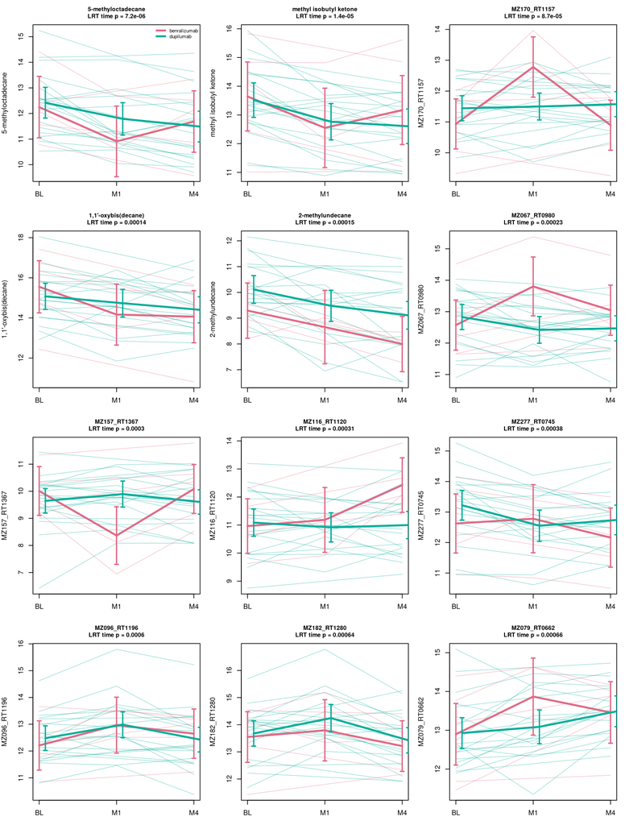

```r
kt(lv[lv$fdr_interaction < 0.05, c("variable", "label", "p_interaction", "fdr_interaction",
                                    "p_time_benralizumab", "p_time_dupilumab", "planted")])
```

| variable | label | p_interaction | fdr_interaction | p_time_benralizumab | p_time_dupilumab | planted |
| --- | --- | --- | --- | --- | --- | --- |
| MZ170_RT1157 | MZ170_RT1157 | 0 | 0.045 | 0.003 | 0.574 |  |
| MZ157_RT1367 | MZ157_RT1367 | 0 | 0.045 | 0.001 | 0.182 |  |

How the two approaches compare:

- The mixed model tests **each fragment** with FDR control across all 3,208. sPLS-DA instead selects a *combination*, which gives no per-VOC error control. The two answer different questions, so report both.
- Four of the five planted VOCs rank in the top five by time effect. 2-ethyl-1-hexanol ranks lower in this simulation (see the printed ranks). At n = 25 only the two strongest pass FDR < 0.05; the others are best described as “top-ranked, not significant after correction”.
- The interaction hits above are *not* planted, so they are false positives. The likely cause is that, with only 5 benralizumab patients, one or two extreme patients can produce a “drug-specific” trajectory. Treat any VOC × biologic finding as exploratory until there are more benralizumab patients.

# 14 Replication scorecard

| item | paper | this_run |
| --- | --- | --- |
| Fragments after contaminant removal | 3208 | 3208 |
| VOCs in final sPLS-DA panel | 5 | 2 |
| Training AUROC (95% CI) | 0.89 (0.79-0.99) | 0.99 (0.96-1.00) |
| LOSO AUROC, fixed panel (95% CI) | 0.78 (0.65-0.91) | 0.99 (0.96-1.00) |
| Nested CV paired accuracy, mean (range) | not done | 0.65 (0.56-0.76) |
| Permutation-null training AUROC (mean) | not done | 0.96 |
| Published 5 VOCs: training / LOSO AUROC | 0.89 / 0.78 | 1.00 / 1.00 |
| 2-ethyl-1-hexanol ~ ACQ (tau, p) | 0.40, 0.008 | 0.48, 0.000771 |
| 1,1’-oxybis(decane) ~ eosinophils (tau, p) | -0.30, 0.035 | -0.43, 0.00238 |

Every “this run” number comes from the synthetic data and will change with the seed. Only the paper column refers to the real cohort.

# 15 What the replication shows

1. **The workflow reproduces end to end with engine skills.** Three methods were missing and are now skills: breath GC-MS preprocessing, multilevel sPLS-DA with backward elimination and LOSO, and the Kendall / Mann–Whitney / paired-change clinical statistics. Two more were added: missing-data diagnosis and imputation benchmarking, and mixed-effects models that use all three visits.
2. **Mixed models add what the paired design throws away.** They keep the 1-month visit and patients with missing samples, and they test drug × time directly. The eosinophil response to the two biologics is opposite, and pooled paired tests average it away.
3. **The published validation is optimistic by design.** Features were selected once on all patients (stated in the paper), so the LOSO-CV of the fixed panel is not independent. The permutation null shows the pipeline can score highly with no effect. The nested estimate and the re-selection frequencies are the numbers to carry forward to the full 3TR-ABC cohort.
4. **The elimination rule is unstable.** “Remove while the AUC drops ≤ 5%” evaluated on the training AUC tends towards one or two features, and which features survive depends on chance. Inside the nested folds it often leaves a single VOC. The skill offers `--elim_auc=loso` and `--target_auc=NA` for sensitivity analyses.
5. **Ambiguities in the paper’s methods,** with the choices made here (all are skill options): relative vs absolute 5% AUC drop (relative); AUC for elimination (training); number of sPLS-DA components (2); how keepX was tuned (sequential LOSO AUC); CI method for Kendall’s tau (bootstrap); the log base and how zeros were handled (log2, half-minimum); the definition of FEV1 ≥ 10% (percentage points).

## 15.1 Methods paragraph (template)

> Exhaled-breath GC-MS feature tables were processed with the DMP-AE `prep-breathomics-gcms` skill: known contaminants were removed, intensities were log2-transformed (zeros set to half the fragment minimum) and batch effects were removed with `limma::removeBatchEffect`, preserving visit. Fragments were z-scored, and within-patient variation was isolated by multilevel decomposition. Sparse PLS-DA (2 components; keepX tuned by leave-one-subject-out AUC) was followed by backward elimination (`ml-multilevel-splsda`; engine: internal). Performance was estimated by patient-grouped 5-fold cross-validation (5 repeats), with keepX tuning and elimination repeated inside each training fold (nested). Significance was assessed against 20 within-patient label permutations. Clinical changes were tested with paired t or Wilcoxon signed-rank tests according to the Shapiro–Wilk test, and baseline associations with Kendall’s tau (`stats-clinical-association`). Longitudinal changes over all three visits were modelled with linear mixed models (visit × biologic fixed effects, random patient intercept; likelihood-ratio tests, BH-FDR across fragments; `stats-mixed-models`).

# 16 Reproducibility

```r
cat("Results folder:", RES, "\nParameters:", paste(names(params), unlist(params), sep = "=", collapse = ", "), "\n")
```

```
## Results folder: usecases/01_breathomics_biologics/results
## Parameters: rerun=0, n_perm=20, boot=2000, seed=2026
```